# Analytics Edge: Unit 4 - Regression Trees for Housing Data

Sulman Khan

October 26, 2018

## “Location, location, location!”

### Boston

- Capital of the state of Massachusetts, USA
- First settled in 1630
- 5 million people in greater Boston Area, some of the highest population densities in America

### Housing Data

- A paper was written on the relationship between **house prices** and **clean air** in the late 1970s by David Harrison of Harvard and Daniel Rubinfeld of U. of Michigan
- Data set widely used to evaluate algorithms

### The R in CART

- Trees can also be used for **regression** - the output at each leaf of the tree is no longer a category, but a number
- Just like classification trees, **regression trees** can capture **nonlinearities** that linear regression can’t

### Regression Trees

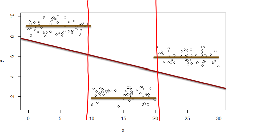

### Housing Data

- We will explore the dataset with the aid of trees
- Compute linear regression with regression trees
- Discussing what the “cp” parameter means
- Apply cross-validation to regression trees

### Understanding the data

- Each entry to a census **tract**, a statistical division of the area that is used by researchers to break down towns and cities
- There will usually be multiple census tracts per **town**
- **LON** and **LAT** are the longitude and latitude of the center of the census tract
- **MEDV** is the median value of owner-occupied homes, in thousands of dollars
- **CRIM** is the per capita crime rate
- **ZN** is related to how much of the land is zoned for large residential properties
- **INDUS** is proportion of area used for industry
- **CHAS** is 1 if the census tract is next to the Charles River
- **NOX** is the concentration of nitrous oxides in the air
- **RM** is the average number of rooms per dwelling
- **AGE** is the proportion of owner-occupied units built before 1940
- **DIS** is a measure of how far the tract is from centers of employment in Boston
- **RAD** is a measure of closeness to important highways
- **TAX** is the property tax rate per $10,000 of value
- **PTRATIO** is the pupil-teacher ratio by town

### The “cp” parameter

- “cp” stands for “complexity parameter”
- Intuition: having too many splits is bad for generalization, so we should penalize the **complexity**
- Our goal when building the tree is to minimize the RSS by making splits, but we want to penalize too many splits. Define **S** to be number of splits, and lambda is the penalty. Our goal is to find the tree that minimizes:

$$\sum\limits_{Leaves} (RSS at each leaf) + \lambda S$$

- lambda = 0.5

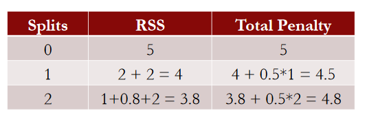

- If we pick a large value of lambda, we won’t make many splits because we pay a big price for every additional split that outweighs the decrease in “error”
- If we pick a small (or zero) value of lambda, we’ll make splits until it no longer decreases error
- The definition of “cp” is closely related to lambda
- Consider a tree with no splits - we simply take the average of the data. Calculate RSS for that tree, let us call it **RSS(no splits)**

$$cp = \frac{\lambda}{RSS(no splits)}$$

# Unit 4, Recitation

### Read in data

```r
# Read in data
boston = read.csv("boston.csv")
# Output structure
str(boston)
```

```
## 'data.frame':    506 obs. of  16 variables:
##  $ TOWN   : Factor w/ 92 levels "Arlington","Ashland",..: 54 77 77 46 46 46 69 69 69 69 ...
##  $ TRACT  : int  2011 2021 2022 2031 2032 2033 2041 2042 2043 2044 ...
##  $ LON    : num  -71 -71 -70.9 -70.9 -70.9 ...
##  $ LAT    : num  42.3 42.3 42.3 42.3 42.3 ...
##  $ MEDV   : num  24 21.6 34.7 33.4 36.2 28.7 22.9 22.1 16.5 18.9 ...
##  $ CRIM   : num  0.00632 0.02731 0.02729 0.03237 0.06905 ...
##  $ ZN     : num  18 0 0 0 0 0 12.5 12.5 12.5 12.5 ...
##  $ INDUS  : num  2.31 7.07 7.07 2.18 2.18 2.18 7.87 7.87 7.87 7.87 ...
##  $ CHAS   : int  0 0 0 0 0 0 0 0 0 0 ...
##  $ NOX    : num  0.538 0.469 0.469 0.458 0.458 0.458 0.524 0.524 0.524 0.524 ...
##  $ RM     : num  6.58 6.42 7.18 7 7.15 ...
##  $ AGE    : num  65.2 78.9 61.1 45.8 54.2 58.7 66.6 96.1 100 85.9 ...
##  $ DIS    : num  4.09 4.97 4.97 6.06 6.06 ...
##  $ RAD    : int  1 2 2 3 3 3 5 5 5 5 ...
##  $ TAX    : int  296 242 242 222 222 222 311 311 311 311 ...
##  $ PTRATIO: num  15.3 17.8 17.8 18.7 18.7 18.7 15.2 15.2 15.2 15.2 ...
```

### Plot observations

```r
# Plot observations
plot(boston$LON, boston$LAT)

# Tracts alongside the Charles River
points(boston$LON[boston$CHAS==1], boston$LAT[boston$CHAS==1], col="blue", pch=19)

# Plot MIT
points(boston$LON[boston$TRACT==3531],boston$LAT[boston$TRACT==3531],col="red", pch=20)

# Plot polution
summary(boston$NOX)
```

```
##    Min. 1st Qu.  Median    Mean 3rd Qu.    Max.
##  0.3850  0.4490  0.5380  0.5547  0.6240  0.8710
```

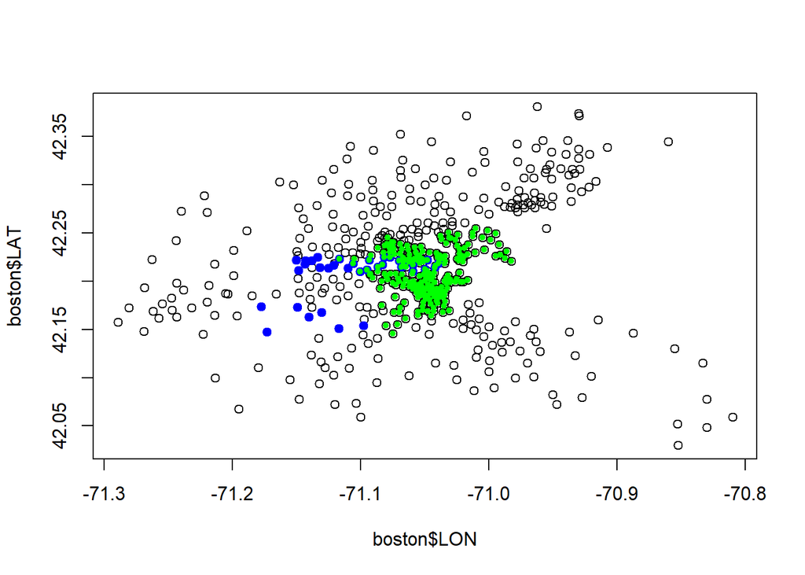

```r
points(boston$LON[boston$NOX>=0.55], boston$LAT[boston$NOX>=0.55], col="green", pch=20)
```

```r
# Plot prices
plot(boston$LON, boston$LAT)
summary(boston$MEDV)
```

```
##    Min. 1st Qu.  Median    Mean 3rd Qu.    Max.
##    5.00   17.02   21.20   22.53   25.00   50.00
```

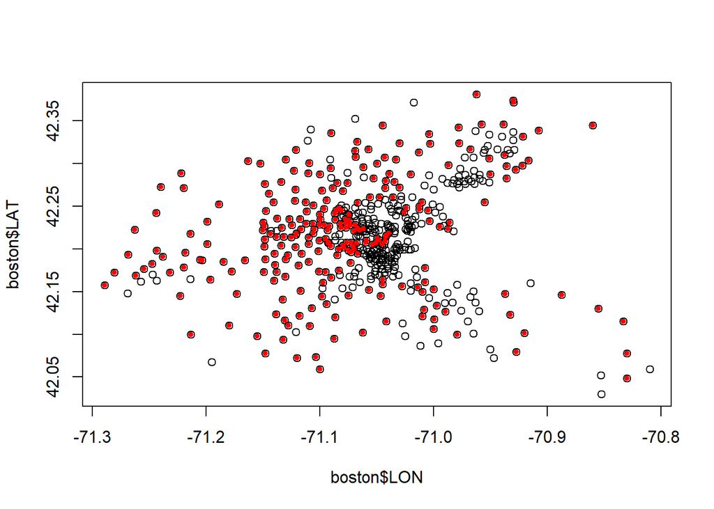

```r
points(boston$LON[boston$MEDV>=21.2], boston$LAT[boston$MEDV>=21.2], col="red", pch=20)
```

### Linear Regression

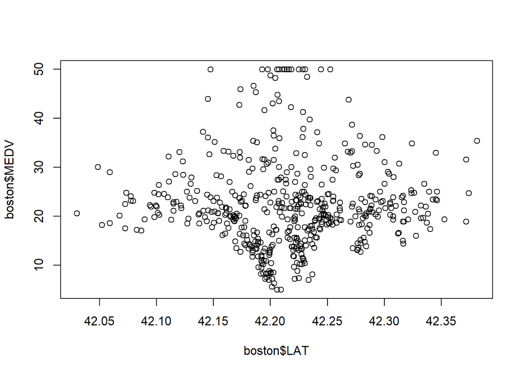

```r
# Linear Regression using LAT and LON
plot(boston$LAT, boston$MEDV)
```

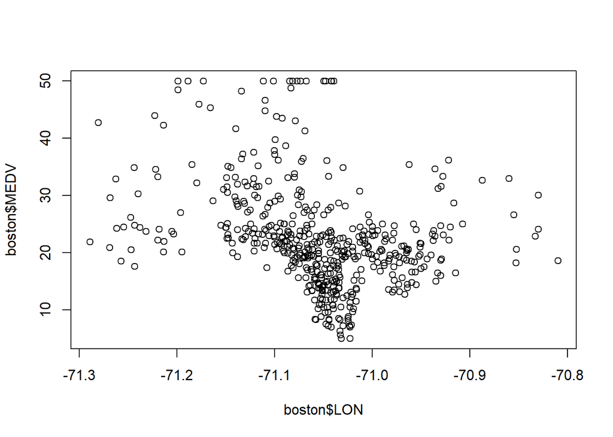

```r
plot(boston$LON, boston$MEDV)
```

```r
latlonlm = lm(MEDV ~ LAT + LON, data=boston)
summary(latlonlm)
```

```
##
## Call:
## lm(formula = MEDV ~ LAT + LON, data = boston)
##
## Residuals:
##     Min      1Q  Median      3Q     Max
## -16.460  -5.590  -1.299   3.695  28.129
##
## Coefficients:
##              Estimate Std. Error t value Pr(>|t|)
## (Intercept) -3178.472    484.937  -6.554 1.39e-10 ***
## LAT             8.046      6.327   1.272    0.204
## LON           -40.268      5.184  -7.768 4.50e-14 ***
## ---
## Signif. codes:  0 '***' 0.001 '**' 0.01 '*' 0.05 '.' 0.1 ' ' 1
##
## Residual standard error: 8.693 on 503 degrees of freedom
## Multiple R-squared:  0.1072, Adjusted R-squared:  0.1036
## F-statistic: 30.19 on 2 and 503 DF,  p-value: 4.159e-13
```

```r
# Visualize regression output
plot(boston$LON, boston$LAT)
points(boston$LON[boston$MEDV>=21.2], boston$LAT[boston$MEDV>=21.2], col="red", pch=20)

latlonlm$fitted.values
```

[output not shown]

[output cut: 16 more lines]

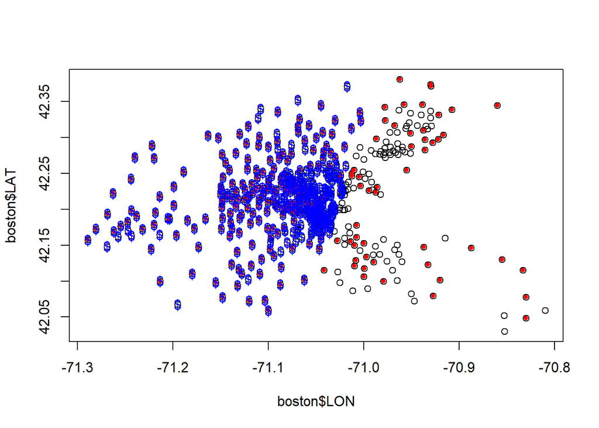

```r
points(boston$LON[latlonlm$fitted.values >= 21.2], boston$LAT[latlonlm$fitted.values >= 21.2], col="blue", pch="$")
```

### CART

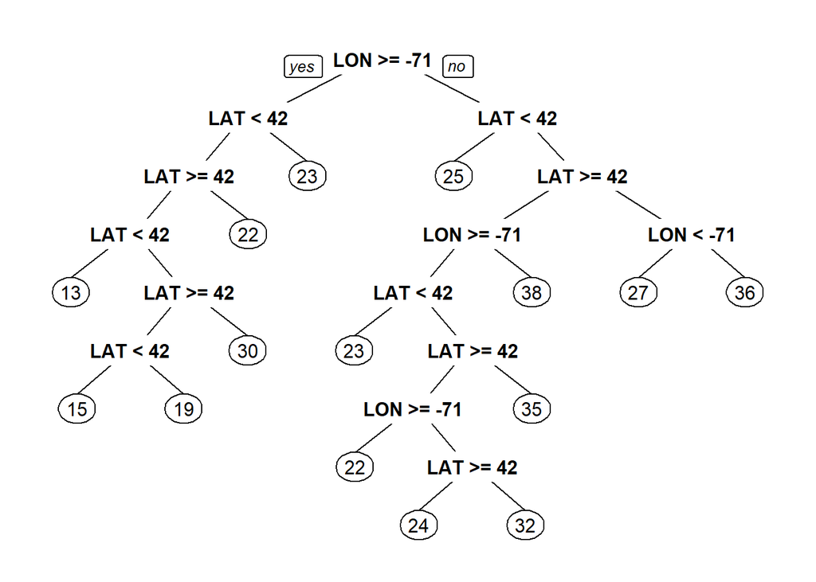

```r
# Load CART packages
library(rpart)
library(rpart.plot)

# CART model
latlontree = rpart(MEDV ~ LAT + LON, data=boston)
prp(latlontree)
```

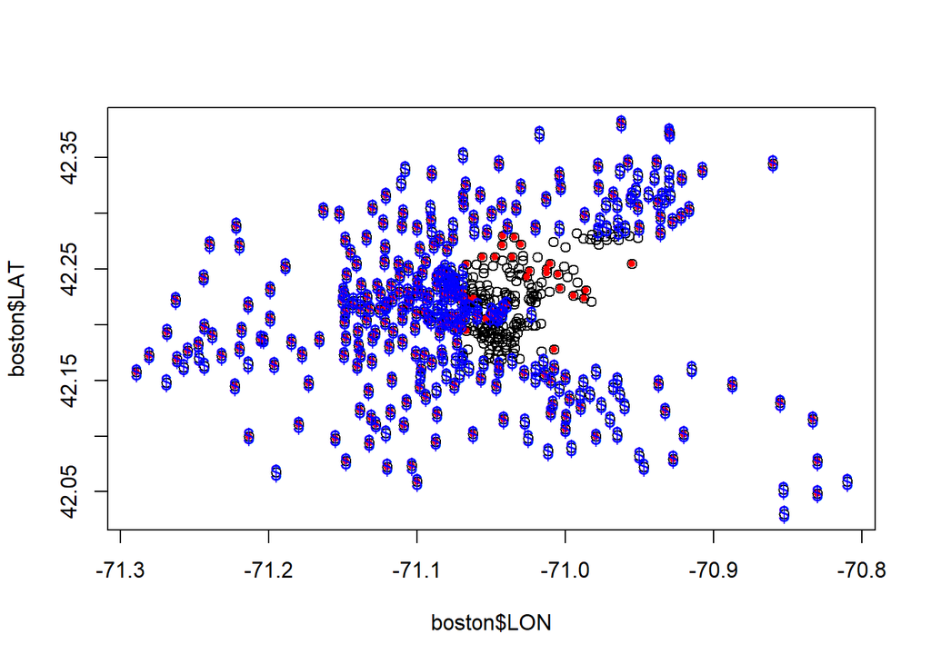

```r
# Visualize output
plot(boston$LON, boston$LAT)
points(boston$LON[boston$MEDV>=21.2], boston$LAT[boston$MEDV>=21.2], col="red", pch=20)

fittedvalues = predict(latlontree)
points(boston$LON[fittedvalues>21.2], boston$LAT[fittedvalues>=21.2], col="blue", pch="$")
```

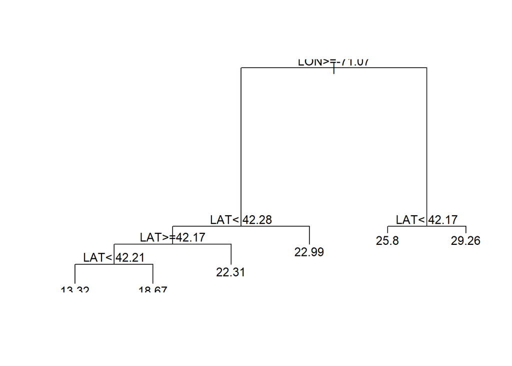

```r
# Simplify tree by increasing minbucket
latlontree = rpart(MEDV ~ LAT + LON, data=boston, minbucket=50)
plot(latlontree)
text(latlontree)
```

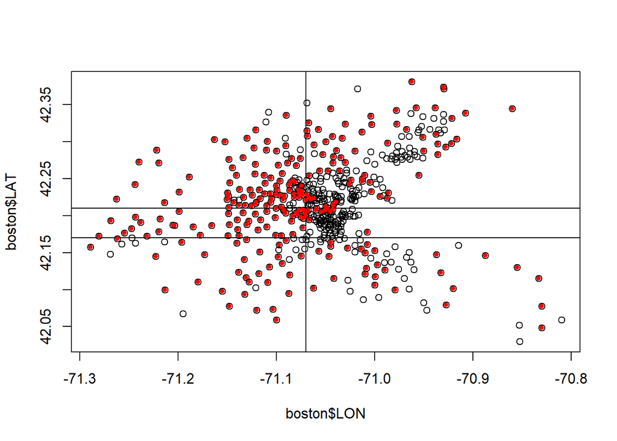

```r
# Visualize Output
plot(boston$LON,boston$LAT)
abline(v=-71.07)
abline(h=42.21)
abline(h=42.17)
points(boston$LON[boston$MEDV>=21.2], boston$LAT[boston$MEDV>=21.2], col="red", pch=20)
```

### Split the data

```r
# Split the data
library(caTools)
set.seed(123)
split = sample.split(boston$MEDV, SplitRatio = 0.7)
train = subset(boston, split==TRUE)
test = subset(boston, split==FALSE)
```

### Linear Regression

```r
# Create linear regression
linreg = lm(MEDV ~ LAT + LON + CRIM + ZN + INDUS + CHAS + NOX + RM + AGE + DIS + RAD + TAX + PTRATIO, data=train)
summary(linreg)
```

```
##
## Call:
## lm(formula = MEDV ~ LAT + LON + CRIM + ZN + INDUS + CHAS + NOX +
##     RM + AGE + DIS + RAD + TAX + PTRATIO, data = train)
##
## Residuals:
##     Min      1Q  Median      3Q     Max
## -14.511  -2.712  -0.676   1.793  36.883
##
## Coefficients:
##                Estimate  Std. Error t value     Pr(>|t|)
## (Intercept) -252.290511  436.710080  -0.578       0.5638
## LAT            1.543965    5.191959   0.297       0.7664
## LON           -2.987111    4.785834  -0.624       0.5329
## CRIM          -0.180802    0.043905  -4.118 0.0000477248 ***
## ZN             0.032503    0.018773   1.731       0.0843 .
## INDUS         -0.042968    0.084731  -0.507       0.6124
## CHAS           2.904178    1.220052   2.380       0.0178 *
## NOX          -21.612794    5.413707  -3.992 0.0000797779 ***
## RM             6.284395    0.482704  13.019      < 2e-16 ***
## AGE           -0.044305    0.017854  -2.482       0.0135 *
## DIS           -1.577356    0.284182  -5.551 0.0000000563 ***
## RAD            0.245089    0.097284   2.519       0.0122 *
## TAX           -0.011123    0.005452  -2.040       0.0421 *
## PTRATIO       -0.983488    0.193886  -5.072 0.0000006382 ***
## ---
## Signif. codes:  0 '***' 0.001 '**' 0.01 '*' 0.05 '.' 0.1 ' ' 1
##
## Residual standard error: 5.595 on 350 degrees of freedom
## Multiple R-squared:  0.665,  Adjusted R-squared:  0.6525
## F-statistic: 53.43 on 13 and 350 DF,  p-value: < 2.2e-16
```

```r
# Make predictions
linreg.pred = predict(linreg, newdata=test)
linreg.sse = sum((linreg.pred - test$MEDV)^2)
linreg.sse
```

```
## [1] 3037.088
```

### CART

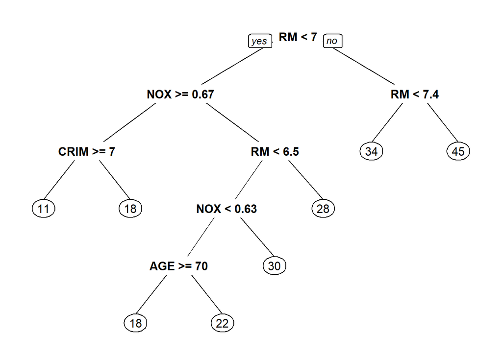

```r
# Create a CART model
tree = rpart(MEDV ~ LAT + LON + CRIM + ZN + INDUS + CHAS + NOX + RM + AGE + DIS + RAD + TAX + PTRATIO, data=train)
prp(tree)
```

```r
# Make predictions
tree.pred = predict(tree, newdata=test)
tree.sse = sum((tree.pred - test$MEDV)^2)
tree.sse
```

```
## [1] 4328.988
```

### Cross-Validation

```r
# Load libraries for cross-validation
library(caret)
library(e1071)

# Number of folds
tr.control = trainControl(method = "cv", number = 10)

# cp values
cp.grid = expand.grid( .cp = (0:10)*0.001)

# What did we just do?
1*0.001
```

```
## [1] 0.001
```

```r
10*0.001
```

```
## [1] 0.01
```

```r
0:10
```

```
##  [1]  0  1  2  3  4  5  6  7  8  9 10
```

```r
0:10 * 0.001
```

```
##  [1] 0.000 0.001 0.002 0.003 0.004 0.005 0.006 0.007 0.008 0.009 0.010
```

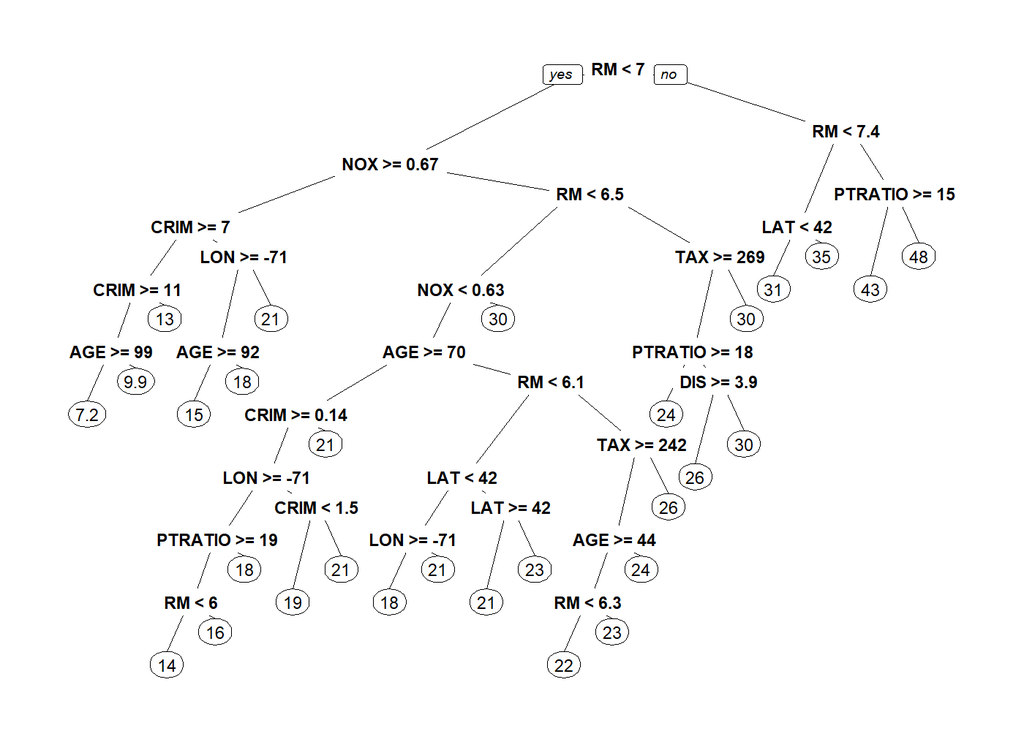

```r
# Cross-validation
tr = train(MEDV ~ LAT + LON + CRIM + ZN + INDUS + CHAS + NOX + RM + AGE + DIS + RAD + TAX + PTRATIO, data = train, method = "rpart", trControl = tr.control, tuneGrid = cp.grid)

# Extract tree
best.tree = tr$finalModel
prp(best.tree)
```

```r
# Make predictions
best.tree.pred = predict(best.tree, newdata=test)
best.tree.sse = sum((best.tree.pred - test$MEDV)^2)
best.tree.sse
```

```
## [1] 3660.149
```